# Artificial_Neural_Networks

## **1. What is Deep Learning?**

Deep Learning is a branch of Machine Learning that is based on Artificial Neural Networks (ANN). In Deep Learning we have 2 domains namely **Natural Language Processing (NLP)** and **Computer Vision**.

In Deep Learning one can pass unstructured data as well as it is suitable for high volumes of data. It is yields comparatively higher accuracy than Machine Learning. The disadvantage of Deep learning is the fact that it requires a very high computational power and a hence an expensive GPU (Graphics Processing Unit) which is not feasible for small scale companies to afford.

## **2. Types of Artificial Neural Networks & their usecases**

Artificial Neural networks are networks that mimic the networking pattern of a human brain consisting of several neurons to yield a high computational output.

The 3 major types of Neural network are:

- Convolutional neural Network (CNN)
- Recurrent neural networks (RNN)
- Long short-term memory networks (LSTMN)

**Artificial Neural Networks (ANN**) constitute the base of Neural networks and can work good for classification.

However if we have an example for Image Classification, then dedicatedly we make use of **Convolutional Neural Networks (CNN)** where we can accurately classify Cat image as Cat and Dog image as a Dog based on their physical features.

**Recurrent neural networks** are used for speech recognition, natural language processing and generally for voice command features.

**Long short-term memory networks** work on Text classification, handwriting recognition and data involving Time series analysis (Stock market data).

## **3. Limitations of Machine Learning & how Deep Learning overcomes it.**

The major limitation of Machine Learning is the fact that it works on structured data and it falls short in performing Image or Text classification. In Deep Learning, the **preprocessing on Text** can be done, which is widely known as **Natural Language Processing (NLP)** and the **one on Image** is done using **OpenCV (Computer Vision)**.

## **4. Understanding how Artificial Neural Network works**

Artificial Neural Networks constitutes of primarily 3 layers:

1. Input layer
2. Hidden Layer/Dense layer (can be multiple)
3. Output layer

All the layers contain neurons which hold information about the data. Unlike Machine Learning here the data is passed as an array to the input. The data comprises of multiple columns combined into 1D array.

Weights are assigned to neurons, which indicates how much importance a neuron gives to a particular attribute (column).

Consider the following diagram before I explain how the model trains on data in Artificial neural Network.

```python
from google.colab import files
from IPython.display import Image
```

```python
uploaded = files.upload()
```

Upload widget is only available when the cell has been executed in the current browser session. Please rerun this cell to enable.

```
Saving ANN_structure.jpg to ANN_structure.jpg
```

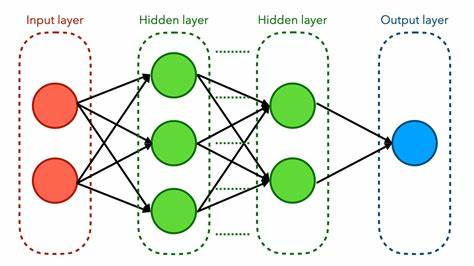

```python
Image('ANN_structure.jpg')
```

Unlike Machine Learning models, Artificial neural networks train & test the data simultaneously. In addition to that, the data is fed row wise instead of an entire chunk of split train data.

This means, the first entry to the the system is the first row of the 1D array. Initially, random weights will be assigned to the neurons and these neurons will then transfer the information from input layer to the hidden layer and predict the output for the output layer. This predicted output will be then compared with the actual output, which will generate an error. This error is called as a 'Loss parameter'. The Loss parameter will be then fed back to the input along with the next row-wise entry. This time the neurons will tune their weights giving and include bias as well and the machine will be again trained on this data. Once again a loss parameter will be generated and fed back to the system along with the next input. Neurons will tune again & bias will be included. This will continue till all the entries of the dataset are trained. **On completion of one cycle on the entire dataset we say the machine has completed one epoch**. More number of epochs will make the machine much robust, since it will be well adapted to learn from it's previous mistakes.

However, while doing so one must remember that too many epochs may also lead to overfitting and too less may lead to underfitting. For those who don't know, Overfitting is a state where a machine trains so much on the training data that it predicts poorly on testing data especially when we have a high variance, while Underfitting is a state where machine trains poorly on training data giving inadequate performance both on training and testing data.

## **5. What is Bias & Activation function?**

Now there is a thin line between weights and bias. Weights tell us the individual importance of a given attribute whereas bias is the tendency of a model to give importance to one of the attributes based on it's learning. Bias is used for shifting the activation function to left or right and is called as the y-intercept in the line equation. To explain it simply, the artificial neural networks takes input and compute the weighted sum of the inputs and includes the bias as well. It is given in the form of a transfer function. Consider the image below to understand the concept more better.

```python
uploaded = files.upload()
```

Upload widget is only available when the cell has been executed in the current browser session. Please rerun this cell to enable.

```
Saving ANN_2.png to ANN_2.png
```

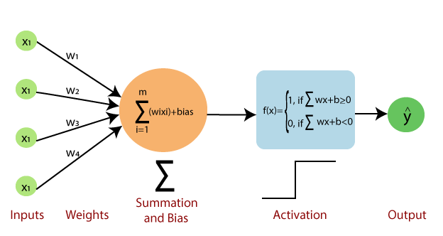

```python
Image('ANN_2.png')
```

An **activation function** on the other hand **decides whether the neuron should be activated or not**. This will decide whether the neuron's input is important or not in predicting the output. So in a way only selected neurons who contribute to good prediction are activated in each training step, or in simple words Activation functions incorporates bias in the system.

There are different types of activation functions like Linear activation function, SoftMax, Relu, Sigmoid, tanh.

Linear activation function is used for Regression.

Sigmoid is used for binary classification.

Softmax is used for multi-class classification.

Relu is used for Image classification (CNN).

Tanh is used for text classification (RNN).

In absence of an Activation function, neurons perform linear transformations on the input, **Activation function adds non-linearity and bias to the entire model**.

## **6. What is Learning rate?**

Learning rate is how fast an algorithm gets trained. It depends on how fast the information is transferred between neurons. A learning rate low indicates that the machine will take time to learn. Higher learning rate requires high computational GPU and hence a high budget.

## **7. Feedforward vs Feedback neural networks**

In Feed forward neural networks only the error is passed to the next input and not the output of the first prediction and in Feed back neural networks along with the error, the output of the first prediction is also fed back to the system.

Example of Feedforward system is CNN. Example of Feedback system is RNN.

## **8. What is empirical loss?**

Empirical loss is basically the combined loss of of an entire epoch. Losses in neural networks are not calculated as row-wise but we get to know the combined loss of an entire epoch.

Consider the following diagram to understand it more better:

```python
uploaded = files.upload()
```

Upload widget is only available when the cell has been executed in the current browser session. Please rerun this cell to enable.

```
Saving empirical_loss.png to empirical_loss.png
```

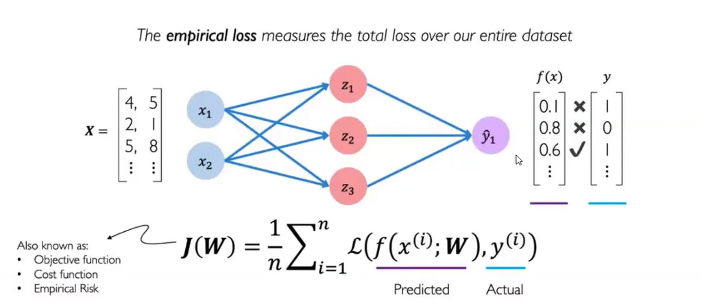

```python
Image('empirical_loss.png',width = 800)
```

As seen from the above image, here X is the i/p 1D array, which is passed through the neurons x1, x2 and through hidden layers z1, z2, z3.

Here the output f(x) is the sum of weighted averages (x1W1 + x2W2) which is passed as an output along with a bias 'b'.

```
      So output, f(x) = ∑(x1w1 + x2W2) + b
```

Coming to the diagram now, here f(x) is the predicted o/p & y is the actual output. The difference between both is loss parameter.

```
      Loss parameter = y - f(x)
```

Empirical loss is the summation of all the Loss parameters for 1 epoch.

For a n-dimensional array,

```
      Empirical loss = ∑(Loss paramteres from 1 to nth row)
```

# **Code**

## **1. Installing the library packages**

We will be working on two libraries, one of them is 'tensorflow' (a very popular library developed by Google) and the second one is 'keras'. So let us install their packages first.

```python
!pip install tensorflow
```

```python
!pip install keras
```

## **2. Importing the libraries & reading the data**

We import the essential libraries form Keras. Sequential & Dense are the ones that will help us further in creating the model.

```python
from keras.models import Sequential
from keras.layers import Dense
import numpy
```

```python
# fix random seed for reproducibility
seed = 7
numpy.random.seed(seed)
# Load the  pima indians dataset
dataset = numpy.loadtxt("https://raw.githubusercontent.com/slmsshk/pima-indians-diabetes.data.csv/main/pima-indians-diabetes.csv", delimiter=",")

X= dataset[:,0:8]
Y = dataset[:,8]
```

In the code above we are using

**numpy.random.seed(seed)**: This line sets the seed for NumPy's random number generator. By setting the seed to the value assigned to seed (which is 7 in this case), the sequence of random numbers generated by NumPy's random functions will be the same each time you run the code. This ensures reproducibility in random number generation using NumPy.

**dataset = numpy.loadtxt("https://raw.githubusercontent.com/slmsshk/pima-indians-diabetes.data.csv/main/pima-indians-diabetes.csv", delimiter=","):** This line loads a dataset into a NumPy array named dataset. The dataset is fetched from a URL provided within the loadtxt function. This dataset appears to be related to diabetes among Pima Indians. The delimiter="," argument specifies that the data is separated by commas.

Let us look at the length of the dataset.

```python
len(dataset)
```

```
768
```

## **3. Creating the model**

After reading the dataset, it is time to create the model. Creating a model is done by defining the input layer, dense layer (hidden layer) and output layer.

```python
# create model
model = Sequential()
model.add(Dense(20,input_dim=8,activation = 'relu')) # first layer (i/p layer)
model.add(Dense(10,activation = 'relu')) # second layer
model.add(Dense(10,activation = 'relu')) # third layer
model.add(Dense(1,activation = 'sigmoid')) # fourth layer (o/p layer)
```

One thing to note here is that we have used sigmoid function as activation for the output which indicates the output is binary classified indicating just 2 outputs.

## **4. Compiling the model**

Once we design our model, the very next step is to compile it. The compilation can be done considering 3 parameters namely **loss, optimizer & metrics**.

```python
#Compiling model
model.compile(loss='binary_crossentropy',optimizer = 'adam',metrics = ['accuracy'])
```

**model.compile**: This is a method used in TensorFlow or Keras to compile a model. Compiling a model means configuring it for training. During compilation, you specify additional settings required to train the model, such as the optimizer, loss function, and evaluation metrics.

**loss='binary_crossentropy':** This specifies the loss function to be used during training. In this case, it's set to 'binary_crossentropy'. Cross-entropy is a commonly used loss function in binary classification problems, where the output of the model is binary (e.g., yes/no, 0/1). It measures the difference between the true labels and the predicted probabilities.

**optimizer='adam':** This specifies the optimizer to be used during training. The optimizer is responsible for updating the weights of the neural network during training in order to minimize the loss function. 'Adam' is a popular optimization algorithm in deep learning that combines ideas from RMSProp and Momentum.

**metrics=['accuracy']:** This specifies the metric(s) to be used to evaluate the performance of the model during training and testing. In this case, it's set to 'accuracy', which is a common metric for classification problems. Accuracy measures the proportion of correct predictions out of all predictions made by the model.

Important things to remember here is that if data is categorical the loss would be categorical_binary_crossentropy or for non categorical classification dataset we use binary_crossentropy.

The optimizer used here is 'adam'.

The metrics used here is accuracy. Some other metrics can be loss, validation loss or validation accuracy.

To check information about the model we use '.summary()' method.

```python
model.summary()
```

```
Model: "sequential"
_________________________________________________________________
 Layer (type)                Output Shape              Param #
=================================================================
 dense (Dense)               (None, 20)                180

 dense_1 (Dense)             (None, 10)                210

 dense_2 (Dense)             (None, 10)                110

 dense_3 (Dense)             (None, 1)                 11

=================================================================
Total params: 511 (2.00 KB)
Trainable params: 511 (2.00 KB)
Non-trainable params: 0 (0.00 Byte)
_________________________________________________________________
```

## **5. Fitting the model**

Similar to a machine Learning model, in Deep Learning as well we fit the model as follows:

```python
history = model.fit(X,Y, validation_split = 0.33, epochs = 250, batch_size = 10)
```

[output not shown]

In the code above we have fitted the model on the split data X & Y where the validation split is 0.33 which is 67% train and 33% test data. The training will be done on the total of 250 epochs. The batch size here indicates the total number of rows inputed to the neurons, a batch size of 10 indicates the model will be trained for 10 rows at a time till it completes 250 epoch cycles.

This concept about regularization that stops the training process of a neural network before it reaches maximum number of epochs is called as '**early stopping**'. The idea is to monitor the performance on the validation set and stop the training when the validation error starts to increase.

More epoch cycles as mentioned earlier may cost high computational GPU and a high expense and hence early stopping is important for regularisation.

## **6. Evaluating the model**

So after training the model we calculate the loss & accuracy.

```python
# evaluate the model
scores = model.evaluate(X,Y)
print("%s: %.2f%%" % (model.metrics_names[1],scores[1]*100))
```

```
accuracy: 76.56%
```

In the above code we are evaluating the model on X & Y.

**print("%s: %.2f%%" % (model.metrics_names[1], scores[1]*100)):** This line prints out one of the performance metrics of the model. It uses string formatting (% operator) to format the output.

**model.metrics_names[1]:** This retrieves the name of the metric being printed. It accesses the second element of the model.metrics_names list (i.e. accuracy) assuming that the first element represents a different metric (like loss).

**scores[1]*100:** This retrieves the value of the corresponding metric from the scores variable and multiplies it by 100 to convert it to a percentage. The index [1] is used assuming that the first metric is something like loss, and the second metric is the one being printed (e.g. accuracy).

**%.2f%%:** This is a format specifier for a floating-point number with two decimal places (%.2f) followed by a percentage sign (%%).

```python
# Visualize training history
# list all the data in history
history.history.keys()
```

```
dict_keys(['loss', 'accuracy', 'val_loss', 'val_accuracy'])
```

history.history.keys() returns a list of all the metric names that were monitored during the training of the model. This information can be useful for analyzing and visualizing the performance of the model during training.

## **7. Plotting the metrics**

Now let us see the plots of accuracy & loss for both train & test data.

### **7.1 Plotting Accuracy vs Validation Accuracy**

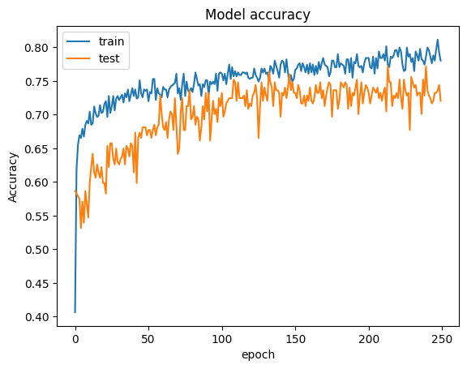

```python
# Summarize history for accuracy

import matplotlib.pyplot as plt
plt.plot(history.history['accuracy'])
plt.plot(history.history['val_accuracy'])
plt.title('Model accuracy')
plt.ylabel('Accuracy')
plt.xlabel('epoch')
plt.legend(['train','test'], loc = 'upper left')
plt.show()
```

**Here train graph is for accuracy and test graph is for val_accuracy.**

### **7.2 Plotting Loss vs Validation Loss**

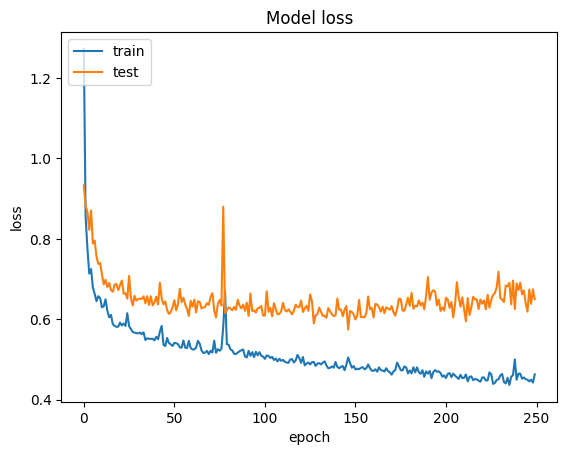

```python
# Summarize history for loss

import matplotlib.pyplot as plt
plt.plot(history.history['loss'])
plt.plot(history.history['val_loss'])
plt.title('Model loss')
plt.ylabel('loss')
plt.xlabel('epoch')
plt.legend(['train','test'], loc = 'upper left')
plt.show()
```

So with this example, we tried to understand how to create, compile & fit the model in Neural Networks followed by plotting the metrics for train & test data and analysing the epoch cycle to see where exactly model attains stability.